# TP2-Bernier-Grabsia

2022-11-28

```r
library(ggplot2)
```

Dans ce TP nous nous intéresserons dans un premier temps aux différents estimateurs de l’axe de symétrie de la densité de deux variable aléatoires : une variable de loi normale de moyenne 5 et d’écart type 2, et une variable de loi uniforme entre 0 et 8. Puis, dans un second temps, nous nous intéresserons à l’application de cette première partie sur l’estimation d’une loi pouvant décrire le poids des poulpes. Enfin, nous utiliserons le test du khi-deux sur un jeu de données représentant le nombre de naissance journalier dans un hopital américain.

#Partie 1

# Partie 1.1

## Question 1

Nous commençons par simuler 500 variables aléatoires indépendantes de loi normale de paramètre (5,2).

```r
X <- rnorm(500, 5, 2)
print(X)
```

```
##   [1]  4.6629773  3.5944627  4.4705502  8.0841692  7.9416084  6.5516395
##   [7]  2.6743344  5.5844561  4.7446297  4.3021018  7.4984610  7.8620699
##  [13]  2.9815144  3.9605440  4.2559822  6.9529620  2.9661980  4.8237659
##  [19] -0.1556263  3.8382871  6.8453921  5.5224577  6.4415292  9.9946727
##  [25]  1.7724663  3.2702785  4.9777615  3.3956715  6.8049228  9.8113533
##  [31]  4.3858042  6.6168473  5.4194002  2.4336770  1.1329338  7.0541729
##  [37]  6.1695814  5.4824076  3.9396421  2.7806627  6.2879203  5.5963824
##  [43]  7.2183454  8.4553053  6.2845164  6.8880964 10.4016375  3.9452130
##  [49]  4.4566059  5.0539017  4.0791822  4.2325832  6.2752547  4.4722384
##  [55]  7.3660037  7.0907251  8.5739719  2.7616853  5.7241776  2.0128294
##  [61]  0.8052049  6.3022587  3.2433524  4.6629438  5.6880349  7.8586787
##  [67]  5.0956501  3.9979337  2.1767001  4.0599556  6.3893103 -1.3357438
##  [73]  6.6497693  4.1895746  6.9098717  6.3997695  8.0245841  6.6352039
##  [79]  9.4691906  6.5972436  2.3937852  5.4384940  4.4818584  4.3173747
##  [85]  4.3942720  9.8739032  5.9965761  4.4095991  5.4309493  4.6939124
```

[output cut: 69 more lines]

## Question 3

```r
estimateurs <- function(x, N, theta)
{
  #Initialise les estimateurs avec un tableau vide
  theta_estim1=rep(0,N)
  theta_estim2=rep(0,N)
  theta_estim3=rep(0,N)

  for (i in 1:N) {
    theta_estim1[i] = mean(x[1:i])
    theta_estim2[i] = median(x[1:i])
    theta_estim3[i] = (min(x[1:i]) + max(x[1:i]))/2
  }


  return(list(theta_estim1 = theta_estim1, theta_estim2 = theta_estim2, theta_estim3 = theta_estim3))
}

ans = estimateurs(X, 500, 5)
```

```r
affiche <- function(ans){
  df_theta_estim1 = data.frame(num = c(1:500), theta1=ans$theta_estim1)
  df_theta_estim2 = data.frame(num = c(1:500), theta2=ans$theta_estim2)
  df_theta_estim3 = data.frame(num = c(1:500), theta3=ans$theta_estim3)

  p1 <- ggplot(df_theta_estim1) +
  aes(x = num, y = theta1) +
  geom_line(colour = "#112446") +
  labs(x = "n",
  y = "theta1", title = expression("Evolution de "~theta~"1 en fonction du nombre de variables considérées")) +
   theme_minimal() +
  theme(plot.title = element_text(hjust = 0.5))

  p2 <- ggplot(df_theta_estim2) +
  aes(x = num, y = theta2) +
  geom_line(colour = "#112446") +
  labs(x = "n",
   y = "theta2", title = expression("Evolution de "~theta~"2 en fonction du nombre de variables considérées")) +
   theme_minimal() +
   theme(plot.title = element_text(hjust = 0.5))

  p3 <- ggplot(df_theta_estim3) +
   aes(x = num, y = theta3) +
   geom_line(colour = "#112446") +
   labs(x = "n",
   y = "theta3", title = expression("Evolution de "~theta~"3 en fonction du nombre de variables considérées")) +
   theme_minimal() +
   theme(plot.title = element_text(hjust = 0.5))

  return(list(p1 = p1, p2 = p2, p3 = p3))
  }
plots = affiche(ans)
```

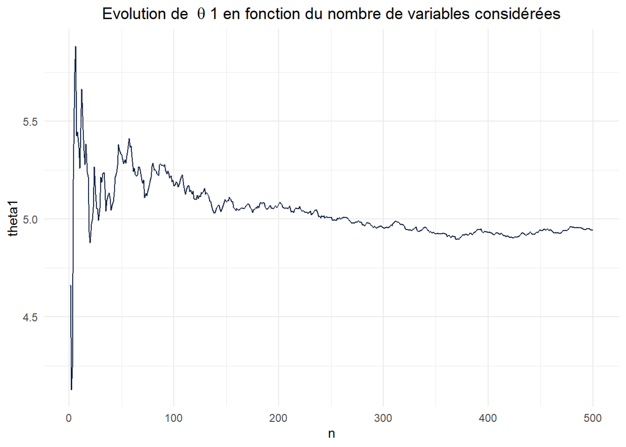

```r
plots$p1
```

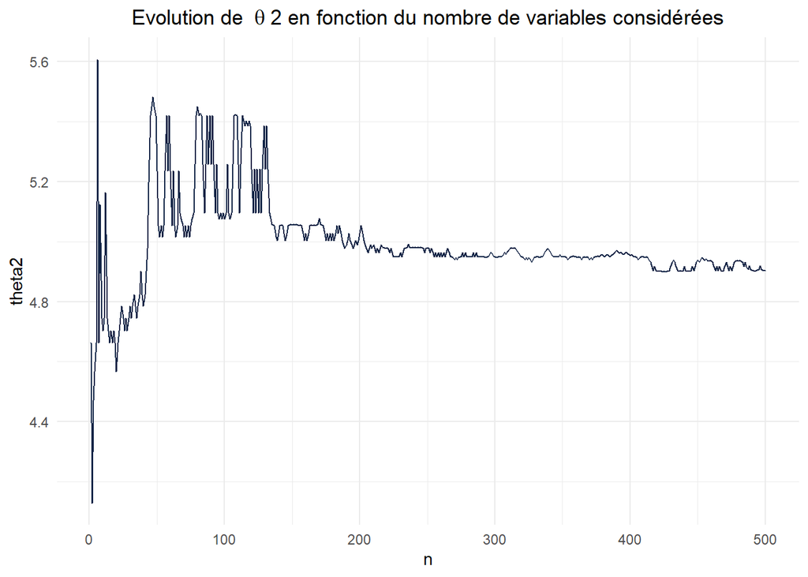

```r
plots$p2
```

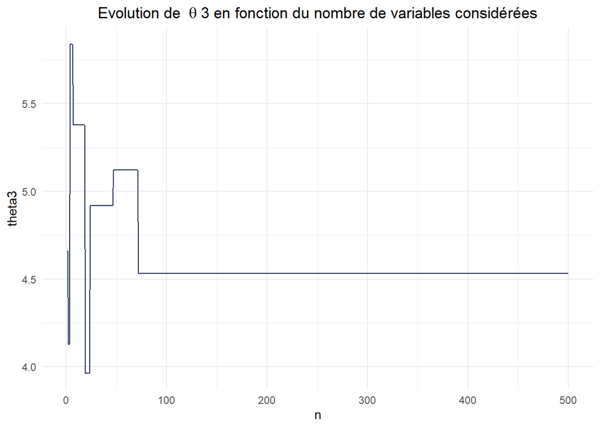

```r
plots$p3
```

## Question 4

```r
biais_et_risques_quadratiques_estimateurs <- function(theta, nb_variables, nb_moyenne, normale = TRUE){

  biais_theta1 = rep(0,200)
  biais_theta2 = rep(0,200)
  biais_theta3 = rep(0,200)

  rq_theta1 =rep(0,200)
  rq_theta2 = rep(0,200)
  rq_theta3 = rep(0,200)

  for (i in 1:nb_moyenne) {
    if (normale){
      x <- rnorm(nb_variables, 5, 2)
    }
    else {
      x <- runif(nb_variables,0, 8)
    }
    ans <- estimateurs(x, nb_variables, theta)
    biais_theta1[i] = mean(ans$theta_estim1)-theta
    biais_theta2[i] = mean(ans$theta_estim2)-theta
    biais_theta3[i] = mean(ans$theta_estim3)-theta
    rq_theta1[i] = mean((ans$theta_estim1 - theta)^2)
    rq_theta2[i] = mean((ans$theta_estim2 - theta)^2)
    rq_theta3[i] = mean((ans$theta_estim3 - theta)^2)

    }

  return (list(biais_theta1 = mean(biais_theta1), biais_theta2 = mean(biais_theta2), biais_theta3 = mean(biais_theta3), rq_theta1 = mean(rq_theta1), rq_theta2 = mean(rq_theta2), rq_theta3 = mean(rq_theta3)))
}
biais <- biais_et_risques_quadratiques_estimateurs(5, 500, 200)
print(biais)
```

```
## $biais_theta1
## [1] -0.003428981
##
## $biais_theta2
## [1] -0.01107453
##
## $biais_theta3
## [1] -0.00830898
##
## $rq_theta1
## [1] 0.05824376
##
## $rq_theta2
## [1] 0.07544253
##
## $rq_theta3
## [1] 0.3370208
```

Concernant les risques quadratiques, on observe que ceux des deux premiers sont beaucoup plus faibles (environ 1% de la valeur que l’on cherche à estimer) que celui du troisième estimateur.

Ainsi, pour une loi normale, le meilleur estimateur est le premier, car c’est celui avec le plus petit biais et le plus petit risque quadratique.

# Partie 1.2

On s’intéresse cette fois-ci à une variable de loi uniforme entre 0 et 8.

## Question 5

```r
X <- runif(500,min=0,max=8)
print(X)
```

```
##   [1] 0.874773227 5.283071842 1.039323153 2.458795976 1.581555080 2.278329741
##   [7] 2.994437957 2.006234540 4.134809246 2.266429717 3.104660450 1.540335601
##  [13] 5.558243170 6.552032931 0.167125514 1.318278264 1.524703829 7.722774748
##  [19] 7.992875207 1.509136008 3.768517645 1.591716366 4.204433251 4.709553685
##  [25] 7.691727960 7.405338679 3.017015681 7.762558728 6.013072219 5.576416805
##  [31] 5.733959069 3.666594110 4.260370197 6.419884525 2.449174518 3.301680986
##  [37] 7.101137575 4.021801474 1.567937862 1.579023063 3.743073659 7.497777468
##  [43] 6.949563619 4.611787641 6.198958263 5.375671368 3.156659570 3.541613206
##  [49] 3.760512963 0.691668265 4.232154688 7.148965644 1.305628207 5.133008584
##  [55] 5.794481253 2.584350156 3.526075121 0.381237747 1.002080627 1.908343676
##  [61] 3.684094880 1.498767342 4.958048858 1.072996218 3.566055868 7.598009078
##  [67] 7.950615630 0.563993804 6.438638261 6.112592816 3.390830865 0.861893589
##  [73] 6.851778990 7.058638226 5.813873509 5.606472706 1.970198121 7.600011267
##  [79] 6.830939695 7.275492257 5.156857481 5.267617766 1.995395144 6.146333309
##  [85] 6.893642306 3.302085483 2.890470253 6.694715589 4.427011086 2.441161273
```

[output cut: 69 more lines]

## Question 6

Dans ce cas là, expression(theta) vaut 0 + 8/2 = 4, car la fonction de densité est uniforme sur l’intervale considéré, donc l’axe de symétrie est le centre de l’intervalle. (Pour tout x dans [0;4] on a bien l’égalité car uniformité, et pour tout x suppérieur, x + et x - sont tous les deux en dehors de l’intervalle, donc la fonction de densité est nulle.)